# Las compuertas XOR

La tabla de verdad está dada por

| p | q | p XOR q |
| --- | --- | --- |
| 1 | 1 | 0 |
| 1 | 0 | 1 |
| 0 | 1 | 1 |
| 0 | 0 | 0 |

### Creación de una red neuronal

Realizamos las importaciones necesarias

```python
import numpy as np
from keras.models import Sequential
from keras.layers.core import Dense
```

Haremos que la información de las columnas `p` y `q` será la información de entrada a nuestra red neuronal, de modo que podremos ingresar a ésta los valores $(1,1), (1,0), (0,1), (0,0)$. Así, crearemos entonces dos nodos de entrada en la primer capa

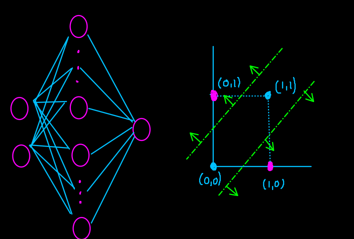

Crearemos una capa oculta de 16 nodos y la capa de salida será de un nodo; la función de activiación `relu` y en la capa de salida será la función `sigmoid`. La información objetivo a la cual queremos llegar son los valores de la columna `p XOR q`: 0, 1, 1, 0.

```python
# Datos de entrenamiento
train = np.array([[0,0], [0,1], [1,0], [1,1]])

# Datos objetivo
target = np.array([[0], [1], [1], [0]])
```

Procedemos a crear la arquitectura de nuestra red neuronal

```python
model = Sequential()
# Capa de entrada de más capa oculta de 16 nodos
model.add(Dense(16, activation='relu', input_shape=(2,)))
# Capa de salida
model.add(Dense(1, activation='sigmoid'))
```

Ahora entrenaremos las red neuronal que acabamos de modelar

```python
# Primero copilamos la red
#            Funcion de perdidad   |   optimizar la       | copilacion del modelo
#                                  |   tasa de aprendizaje| paso a paso
model.compile(loss='mean_squared_error', optimizer='adam', metrics=['binary_accuracy'])

# Entrenamos la red
#                        Cantidad de iteraciones
#                        de aprendizaje de
#                        entrenamiento
model.fit(train, target, epochs=150)
```

```
<keras.callbacks.History at 0x1d2bdb860d0>
```

```python
scores = model.evaluate(train, target)
print('%s: %.4f%%' % (model.metrics_names[1], scores[1] * 100))
```

```
binary_accuracy: 100.0000%
```

Podemos guardar nuestro modelo:

```python
from keras.models import load_model
model.save('XOR.h5')
```

Y posteriormento lo podremos utilizar cuando queramos, por ejemplo vamos a utilizarlo para hacer predicciones, lo cual no tendría mucho sentido para nuestro ejemplo pues la red neuronal dará el valor correcto a las 4 posibilidades de la tabla de verdad del XOR

```python
# Cargamos el modelo guardado
model_xor = load_model('XOR.h5')

# Hacemos las 4 predicciones posibles de XOR
pred = model_xor.predict(train)
pred
```

```
array([[0.4879571 ],
       [0.57188183],
       [0.61815906],
       [0.40221503]], dtype=float32)
```

Lo cual podemos ver de manera más visual si realizamos el redondeo, pues lo anterior nos arroja probabilidades (lo cual logramos con la función de activación sigmoide, donde el umbral por defecto es 0.5)

```python
pred.round()
```

```
array([[0.],
       [1.],
       [1.],
       [0.]], dtype=float32)
```